# PracticalMachineLearning

Sasa Pakvovic

Saturday, December 20, 2014

# Background

Using devices such as Jawbone Up, Nike FuelBand, and Fitbit it is now possible to collect a large amount of data about personal activity relatively inexpensively. These type of devices are part of the quantified self movement  a group of enthusiasts who take measurements about themselves regularly to improve their health, to find patterns in their behavior, or because they are tech geeks. One thing that people regularly do is quantify how much of a particular activity they do, but they rarely quantify how well they do it. In this project, your goal will be to use data from accelerometers on the belt, forearm, arm, and dumbell of 6 participants. They were asked to perform barbell lifts correctly and incorrectly in 5 different ways. More information is available from the website [here:](http://groupware.les.inf.puc-rio.br/har) (see the section on the Weight Lifting Exercise Dataset).

### Data

The data comes form this [source](http://groupware.les.inf.puc-rio.br/har).

### Analysis

We will be using data acquired to build up a model to be able to predict how well the practicioner is doing the exercise. For this purpose we will be creating random forest model because of its robustness in many situations.

### Data sliceing

We will be using some of the available R packages to prepare the model.

```r
library(caret)
library(kernlab)
library(randomForest)
```

```r
library(corrplot)
set.seed(1050)
```

After loading and looking a little bit at the data using eploratory data analysis very soon is clear that data has a lot of NAs and has columns which can not help us in building a model(metadata).

```r
# cleaning of the data needed
trainNAs <- apply(train, 2, function(x) {sum(is.na(x))})
trainclean <- train[,which(trainNAs==0)]

# for prediction we will not include firsr 8 rows
trainclean <- trainclean[8:length(trainclean)]
```

### Model building

On clean data we need to divide the train data set into training and cross-validation datasets. Iv decided to take a 80/20 split.

```r
# split the train data into 2 sets - training and cross validation
inTrain <- createDataPartition(y = trainclean$classe, p = 0.8, list = FALSE)
training <- trainclean[inTrain, ]
cval <- trainclean[-inTrain, ]
```

We can take a look at the correlation matrix of all the predictors.

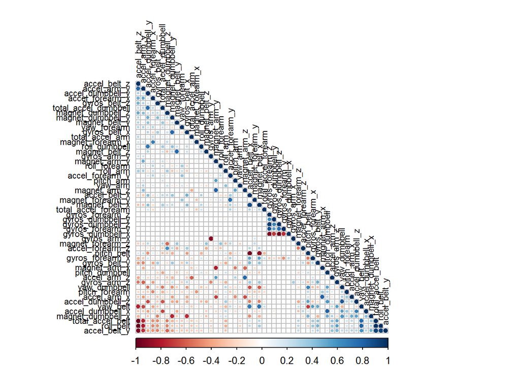

```r
# calc the correlation matrix
cormatrix <- cor(training[, -length(training)])
corrplot(cormatrix, order = "FPC", method = "circle", type = "lower", tl.cex = 0.7,  tl.col = rgb(0, 0, 0))
```

We are going to deploy a radnom forest model to predict classe using all other feautres as predictors. We will use crossvalidation to build up a confusion matrix and check how the model is performing.

```r
# fit a radnom forest model
modelFit <- randomForest(classe ~ ., data = training)
# crossvalidate the model
predictCVal <- predict(modelFit, cval)
confusionMatrix(cval$classe, predictCVal)
```

```
## Confusion Matrix and Statistics
##
##           Reference
## Prediction    A    B    C    D    E
##          A 1115    1    0    0    0
##          B    1  757    1    0    0
##          C    0    4  680    0    0
##          D    0    0    2  640    1
##          E    0    0    2    0  719
##
## Overall Statistics
##
##                Accuracy : 0.997
##                  95% CI : (0.995, 0.998)
##     No Information Rate : 0.284
##     P-Value [Acc > NIR] : <2e-16
##
##                   Kappa : 0.996
##  Mcnemar's Test P-Value : NA
##
## Statistics by Class:
##
##                      Class: A Class: B Class: C Class: D Class: E
## Sensitivity             0.999    0.993    0.993    1.000    0.999
## Specificity             1.000    0.999    0.999    0.999    0.999
## Pos Pred Value          0.999    0.997    0.994    0.995    0.997
## Neg Pred Value          1.000    0.998    0.998    1.000    1.000
## Prevalence              0.284    0.194    0.175    0.163    0.184
## Detection Rate          0.284    0.193    0.173    0.163    0.183
## Detection Prevalence    0.284    0.193    0.174    0.164    0.184
## Balanced Accuracy       0.999    0.996    0.996    1.000    0.999
```

### Using the model on the test dataset

Only thing left to do is use our model on the the test dataset and predict the classes of classe.

```r
# now use the model on the test data
test <- read.csv("./data/testpml", na.strings= c("NA",""," "))
testNAs <- apply(test, 2, function(x) {sum(is.na(x))})
testclean <- test[,which(testNAs==0)]
testclean <- testclean[8:length(testclean)]
predictTest <- predict(modelFit, testclean)
predictTest
```

```
##  1  2  3  4  5  6  7  8  9 10 11 12 13 14 15 16 17 18 19 20
##  B  A  B  A  A  E  D  B  A  A  B  C  B  A  E  E  A  B  B  B
## Levels: A B C D E
```